# **Analisis del modelo**

Camilo Portilla

2025-10-9

```r
knitr::opts_chunk$set(
  message = FALSE,
  warning = FALSE,
  echo = FALSE)

# Cargar librerías sin mostrar mensajes
suppressPackageStartupMessages({
  library(tidyverse)
  library(scales)
  library(readxl)
  library(ggcorrplot)
  library(visreg)
  library(nortest)
  library(lmtest)
  library(ggthemes)
  library(ggpmisc)
  library(DT)
  library(plotly)
  library(kableExtra)
  library(car)
  library(broom)})

datos_hogar=read.csv("datos_hogar.csv", sep = ";") %>%
  select(DIRECTORIO,I_HOGAR,PERCAPITA,CANT_PERSONAS_HOGAR) %>%
  rename("Ingreso del hogar"=2,"Cantidad de personas en el hogar"=4) %>%
  distinct(DIRECTORIO, .keep_all = TRUE) %>% filter(`Ingreso del hogar`!=0)


educacion=read.csv("educacion.csv", sep= ";") %>%
  select(DIRECTORIO,P8587) %>%
  group_by(DIRECTORIO) %>%
  filter(P8587 == max(P8587))  %>%
  ungroup() %>%
  distinct(DIRECTORIO, .keep_all = TRUE) %>%
  mutate(
    Estudios = case_when(
      P8587 == 1 ~ "Ninguno",
      P8587 == 2 ~ "Preescolar",
      P8587 == 3 ~ "Primaria (1º-5º)",
      P8587 == 4 ~ "Secundaria (6º-9º)",
      P8587 == 5 ~ "Media (10º-13º)",
      P8587 == 6 ~ "Técnico sin título",
      P8587 == 7 ~ "Técnico con título",
      P8587 == 8 ~ "Tecnológico sin título",
      P8587 == 9 ~ "Tecnológico con título",
      P8587 == 10 ~ "Universitario sin título",
      P8587 == 11 ~ "Universitario con título",
      P8587 == 12 ~ "Postgrado sin título",
      P8587 == 13 ~ "Postgrado con título",
      TRUE ~ "No especificado"
    ),
    CATEGORIA_EDUCATIVA = case_when(
      P8587 %in% 1:2 ~ "Primaria",
      P8587 %in% 3:5 ~ "Secundaria",
      P8587 %in% 6:9 ~ "Técnica/Tecnológica",
      P8587 %in% 10:11 ~ "Universitaria",
      P8587 %in% 12:13 ~ "Postgrado",
      TRUE ~ "Otro"
    ),    CATEGORIA_EDUCATIVA = factor(CATEGORIA_EDUCATIVA,
                                       levels = c("Primaria", "Secundaria", "Técnica/Tecnológica",
                                                  "Universitaria", "Postgrado")))

caracteristicas_hogar=read.csv("Características_composición.CSV",sep= ";") %>%
  filter(P6051==1) %>%
  select(DIRECTORIO,P6020,P6040,P6051,P5502,P1895) %>% rename(Sexo=2,Edad=3,Parentesco=4,Casado=5,
                                                              sastifacion=6)

tenencia=read.csv("tenencia y financiación de la vivienda.CSV",sep=";") %>%
  filter(P5130!=99) %>%
  mutate(Arriendo_estimacion=rowSums(select(., P5130, P5140), na.rm = TRUE)) %>%
  select(DIRECTORIO,Arriendo_estimacion) %>%
  distinct(DIRECTORIO, .keep_all = TRUE)


trabajo=read.csv("Fuerza de trabajo.CSV",sep=";") %>%
  select(DIRECTORIO,P8624,P415,P8634,P6426,P416,P6440,P6460,P6426,P8636) %>%
  rename(Ingresos_mes=2,Horas_trabajadas_semana=3,"Lugar de trabajo"=4,Tiempo_trabajado=5,
         Semana_horas=6,contrato=7,Tipo_contrato=8,
         meses=8)


vivienda=read.csv("Datos de la vivienda.csv",sep=";") %>%
  select(DIRECTORIO,CLASE,P1_DEPARTAMENTO) %>% rename(Ubicacion=2,Departamento=3) %>%
  distinct(DIRECTORIO, .keep_all = TRUE)

salud=read.csv("Salud.CSV", sep=";")  %>%
  select(DIRECTORIO,P6090) %>%
  group_by(DIRECTORIO) %>%
  filter(P6090 == max(P6090)) %>%
  rename(Afiliado=2)%>%
  ungroup() %>%
  distinct(DIRECTORIO, .keep_all = TRUE)

Muestra=read.csv("muestral.CSV",sep=";") %>%
  select(DIRECTORIO,MPIO) %>% rename(Municipio=2) %>%
  distinct(DIRECTORIO, .keep_all = TRUE)

#Base de datos final

suppressWarnings({
  Base_datos <- caracteristicas_hogar %>%
    inner_join(datos_hogar, by = "DIRECTORIO") %>%
    inner_join(vivienda, by = "DIRECTORIO") %>%
    inner_join(educacion, by = "DIRECTORIO") %>%
    inner_join(trabajo, by = "DIRECTORIO") %>%
    filter(
      Departamento %in% c(76, 19, 52, 27),
      Edad != 0, Edad >= 18,
      `Ingreso del hogar` <= 50000000
    ) %>%
    select(
      Departamento, `Ingreso del hogar`, `Cantidad de personas en el hogar`, Sexo,
      Edad, CATEGORIA_EDUCATIVA, Tiempo_trabajado, Horas_trabajadas_semana, sastifacion
    ) %>%
    mutate(
      Departamento = case_when(
        Departamento == 76 ~ "Valle del Cauca",
        Departamento == 19 ~ "Cauca",
        Departamento == 52 ~ "Nariño",
        Departamento == 27 ~ "Chocó"
      ),
      Sexo = case_when(
        Sexo == 1 ~ "Hombre",
        Sexo == 2 ~ "Mujer"))
})

# tema
tema_powerbi <- theme_minimal() +
  theme(text = element_text(family = "Segoe UI", color = "#2d3748"),
  plot.title = element_text(face = "bold", size = 18, hjust = 0.5, color = "#323130"),
  plot.subtitle = element_text(size = 12, hjust = 0.5, color = "#605e5c", margin = margin(b = 15)),
  plot.caption = element_text(size = 10, color = "#605e5c", hjust = 0),
  panel.grid.major = element_line(color = "#f3f2f1"),
  panel.grid.minor = element_blank(),
  plot.background = element_rect(fill = "white", color = NA),
  panel.background = element_rect(fill = "white", color = NA),
  axis.title = element_text(face = "bold", color = "#323130"),
  axis.text = element_text(color = "#605e5c"),
  legend.position = "none")
```

# Resultados del modelo

En esta sección se presentan los resultados del modelo de regresión lineal estimado.  
Inicialmente se analiza la asociación entre la variable dependiente y las variables explicativas mediante el coeficiente de correlación de Pearson. Posteriormente, se resume la bondad de ajuste del modelo utilizando el análisis de varianza (ANOVA) y el resumen del modelo.

Finalmente, se valida el cumplimiento de los supuestos clásicos del modelo lineal:  
(1) la media de los errores es cero,  
(2) la varianza de los errores es constante (homocedasticidad),  
(3) los errores son aleatorios e independientes entre sí, y  
(4) los errores se distribuyen normalmente.

Coeficiente de Correlación de Pearson con la Variable Dependiente

| Variable | Coef. de Pearson (r) | Valor p | Significativo |
| --- | --- | --- | --- |
| Cantidad de personas en el hogar | 0.178 | 2e-16 | Sí |
| Edad | 0.018 | 4.248e-02 | Sí |
| Tiempo_trabajado | 0.272 | 2e-16 | Sí |
| Horas_trabajadas_semana | 0.116 | 2e-16 | Sí |
| sastifacion | 0.123 | 2e-16 | Sí |

Nota:  
Elaboración propia con base en ECV DANE 2024

## Resultados del modelo y ANOVA

Resultados del modelo de regresión lineal múltiple

Variable

Coeficiente

Error Estándar

Estadístico t

Valor p

Sig.

(Intercept)

13.01036

0.20679

62.91636

2e-16

***

SexoMujer

-0.08399

0.02883

-2.91371

3.610e-03

Tiempo_trabajado

0.00127

0.00016

8.16733

2e-16

***

CATEGORIA_EDUCATIVASecundaria

0.00139

0.18013

0.00774

9.938e-01

CATEGORIA_EDUCATIVATécnica/Tecnológica

0.40802

0.1829

2.23089

2.579e-02

CATEGORIA_EDUCATIVAUniversitaria

0.80808

0.18261

4.42513

1.000e-05

***

CATEGORIA_EDUCATIVAPostgrado

1.49274

0.18495

8.07089

2e-16

***

`Cantidad de personas en el hogar`

0.22414

0.01222

18.33766

2e-16

***

Edad

0.00099

0.00095

1.0413

2.979e-01

sastifacion

0.034

0.00913

3.72561

2.000e-04

***

Horas_trabajadas_semana

0.00998

0.0011

9.03523

2e-16

***

DepartamentoChocó

0.16721

0.05488

3.04675

2.340e-03

DepartamentoNariño

-0.02288

0.04207

-0.54384

5.866e-01

DepartamentoValle del Cauca

0.09099

0.03785

2.40416

1.629e-02

R² ajustado

0.4756

F

151.01

Valor p (modelo)

1.17e-290

N

2151

Nota: Elaboración propia con base en ECV DANE 2024.

## Validacion de los supuestos

### Media cero de los residuos

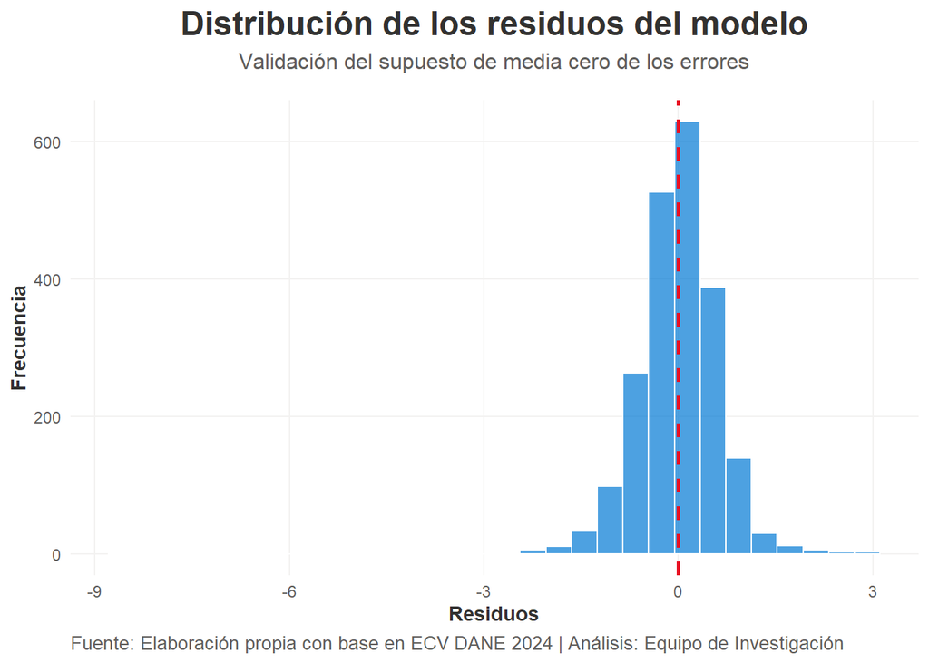

[interactive chart not shown]

### Normalidad de los residuos

[interactive chart not shown]

### Varianza constante(homocedasticidad)

[interactive chart not shown]

### Independencia de los errores

[interactive chart not shown]

### Observaciones influyentes

[interactive chart not shown]

## Análisis estadístico de los supuestos (Pruebas de hipótesis)

Pruebas de Hipótesis para la Validación de Supuestos del Modelo

| Supuesto evaluado | Prueba aplicada | Hipótesis nula (H₀) | Valor p / Estadístico | Resultado |
| --- | --- | --- | --- | --- |
| Normalidad de los residuos (Shapiro–Wilk) | Shapiro–Wilk | Los residuos siguen una distribución normal | p = 5.9e-31 | p < 0.05 → Se rechaza H₀ |
| Normalidad de los residuos (Lilliefors) | Lilliefors (Kolmogorov–Smirnov) | Los residuos siguen una distribución normal | p = 2.65e-15 | p < 0.05 → Se rechaza H₀ |
| Varianza constante (homocedasticidad) | Breusch–Pagan | La varianza de los errores es constante | p = 0.244 | p > 0.05 → No se rechaza H₀ |
| Ausencia de multicolinealidad | Factor de inflación de varianza (VIF) | No existe colinealidad entre predictores | Máx VIF = 4 | VIF < 5 → Cumple |

Nota: Fuente: Elaboración propia con base en ECV DANE 2024 y pruebas estadísticas aplicadas a los residuos del modelo.

## Algunas predicciones

Predicción del Ingreso del Hogar según Características Simuladas

| Departamento | Sexo | CATEGORIA_EDUCATIVA | Edad | Tiempo trabajado | Cantidad de personas | Horas semanales | Satisfacción | Ingreso Predicho |
| --- | --- | --- | --- | --- | --- | --- | --- | --- |
| Valle del Cauca | Hombre | Secundaria | 25 | 12 | 3 | 40 | 7 | 1876442 |
| Cauca | Mujer | Universitaria | 35 | 24 | 4 | 45 | 8 | 5002037 |
| Nariño | Hombre | Técnica/Tecnológica | 45 | 36 | 2 | 35 | 6 | 1968889 |
| Choco | Mujer | Postgrado | 55 | 48 | 5 | 50 | 9 | 16612608 |

Nota: Las predicciones corresponden al ingreso estimado (en pesos) a partir del modelo ajustado en logaritmo natural.